# Tarea 1 Corregida: Análisis de Componentes Principales

Arantza Ivonne Pineda Sandoval_141194

# Introducción

En este trabajo de utilizará la base de datos correspondiente al tipo de cambio en diferentes economías del mundo (“est46114_s06_data.xls”).

1. Reportar qué economia tiene el mayor peso esperado en la descomposicion.
2. Reportar qué economia tiene la mayor consistencia en estimacion de los $c_{j,s}$ correspondientes.

Para comenzar el análisis, se realizará un estudio preliminar de los datos para entender el modo más adecuado de proceder con el análisis.

Se cargan librerías útiles para el manejo de datos:

```r
knitr::opts_chunk$set(echo = TRUE)
library("tidyverse")
library("lubridate")
library(readxl)
```

A continuación se lee la base de datos y se realiza una inspección:

```r
tipo_de_cambio <- read_xls('est46114_s06_data.xls')
head(tipo_de_cambio)
```

```
## # A tibble: 6 x 81
##   Date                Canada Mexico Guatemala `El Salvador` Honduras
##   <dttm>               <dbl>  <dbl>     <dbl>         <dbl>    <dbl>
## 1 1970-01-01 00:00:00   1.11   9.38      7.53          20.2     14.4
## 2 1970-02-01 00:00:00   1.11   9.42      7.61          20.1     14.5
## 3 1970-03-01 00:00:00   1.11   9.45      7.78          20.2     14.5
## 4 1970-04-01 00:00:00   1.11   9.50      7.84          20.4     14.5
## 5 1970-05-01 00:00:00   1.12   9.51      7.74          20.5     14.5
## 6 1970-06-01 00:00:00   1.08   9.51      7.43          20.2     14.5
## # … with 75 more variables: Nicaragua <dbl>, `Costa Rica` <dbl>,
## #   Panama <dbl>, Jamaica <dbl>, `Dominican Rep` <dbl>,
## #   `Trin/Tobago` <dbl>, Colombia <dbl>, Venezuela <dbl>, Ecuador <dbl>,
## #   Peru <dbl>, Chile <dbl>, Brazil <dbl>, Paraguay <dbl>, Uruguay <dbl>,
## #   Argentina <dbl>, EU12 <dbl>, Sweden <dbl>, Norway <dbl>,
## #   Finland <dbl>, Denmark <dbl>, U.K. <dbl>, Ireland <dbl>,
## #   Luxembourg <dbl>, Netherlands <dbl>, France <dbl>, Germany <dbl>,
## #   Austria <dbl>, `Czech Rep` <dbl>, Hungary <dbl>, Switzerland <dbl>,
## #   Poland <dbl>, Russia <dbl>, Spain <dbl>, Portugal <dbl>, Italy <dbl>,
## #   Greece <dbl>, Turkey <dbl>, Syria <dbl>, Israel <dbl>, Jordan <dbl>,
## #   Kuwait <dbl>, `Saudi Arabia` <dbl>, India <dbl>, Pakistan <dbl>,
## #   Bangladesh <dbl>, `Sri Lanka` <dbl>, Thailand <dbl>, Malaysia <dbl>,
## #   Singapore <dbl>, Indonesia <dbl>, Philippines <dbl>, `China,PR` <dbl>,
## #   Korea <dbl>, `Hong Kong` <dbl>, Taiwan <dbl>, Japan <dbl>,
## #   Australia <dbl>, `New Zealand` <dbl>, Morocco <dbl>, Algeria <dbl>,
## #   Tunisia <dbl>, Egypt <dbl>, Cameroon <dbl>, Senegal <dbl>, `Sierra
## #   Leone` <dbl>, `Cote d'Ivoire` <dbl>, Ghana <dbl>, Nigeria <dbl>,
## #   Benin <dbl>, Congo <dbl>, Kenya <dbl>, Tanzania <dbl>,
## #   Mozambique <dbl>, `South Africa` <dbl>, Zambia <dbl>
```

```r
tail(tipo_de_cambio)
```

```
## # A tibble: 6 x 81
##   Date                Canada Mexico Guatemala `El Salvador` Honduras
##   <dttm>               <dbl>  <dbl>     <dbl>         <dbl>    <dbl>
## 1 2010-07-01 00:00:00   1.08   11.5      6.37          8.25     15.3
## 2 2010-08-01 00:00:00   1.08   11.4      6.27          8.25     15.2
## 3 2010-09-01 00:00:00   1.08   11.4      6.18          8.25     15.2
## 4 2010-10-01 00:00:00   1.08   11.4      6.11          8.26     15.2
## 5 2010-11-01 00:00:00   1.09   11.5      6.03          8.26     15.1
## 6 2010-12-01 00:00:00   1.09   11.5      5.95          8.26     15.1
## # … with 75 more variables: Nicaragua <dbl>, `Costa Rica` <dbl>,
## #   Panama <dbl>, Jamaica <dbl>, `Dominican Rep` <dbl>,
## #   `Trin/Tobago` <dbl>, Colombia <dbl>, Venezuela <dbl>, Ecuador <dbl>,
## #   Peru <dbl>, Chile <dbl>, Brazil <dbl>, Paraguay <dbl>, Uruguay <dbl>,
## #   Argentina <dbl>, EU12 <dbl>, Sweden <dbl>, Norway <dbl>,
## #   Finland <dbl>, Denmark <dbl>, U.K. <dbl>, Ireland <dbl>,
## #   Luxembourg <dbl>, Netherlands <dbl>, France <dbl>, Germany <dbl>,
## #   Austria <dbl>, `Czech Rep` <dbl>, Hungary <dbl>, Switzerland <dbl>,
## #   Poland <dbl>, Russia <dbl>, Spain <dbl>, Portugal <dbl>, Italy <dbl>,
## #   Greece <dbl>, Turkey <dbl>, Syria <dbl>, Israel <dbl>, Jordan <dbl>,
## #   Kuwait <dbl>, `Saudi Arabia` <dbl>, India <dbl>, Pakistan <dbl>,
## #   Bangladesh <dbl>, `Sri Lanka` <dbl>, Thailand <dbl>, Malaysia <dbl>,
## #   Singapore <dbl>, Indonesia <dbl>, Philippines <dbl>, `China,PR` <dbl>,
## #   Korea <dbl>, `Hong Kong` <dbl>, Taiwan <dbl>, Japan <dbl>,
## #   Australia <dbl>, `New Zealand` <dbl>, Morocco <dbl>, Algeria <dbl>,
## #   Tunisia <dbl>, Egypt <dbl>, Cameroon <dbl>, Senegal <dbl>, `Sierra
## #   Leone` <dbl>, `Cote d'Ivoire` <dbl>, Ghana <dbl>, Nigeria <dbl>,
## #   Benin <dbl>, Congo <dbl>, Kenya <dbl>, Tanzania <dbl>,
## #   Mozambique <dbl>, `South Africa` <dbl>, Zambia <dbl>
```

Se observa que existen 80 países y los datos cubren diferentes años, sin embargo se elige realizar un análisis de tipo anual por lo que será necesario tomar un año en específico, por ejemplo, el año 2000.

# Supuestos del modelo PCA

El modelo de PCA asume ciertos supuestos que se deben cumplir para los datos:

1. Media constante por renglón.
2. Varianza constante por renglón.
3. Homogeneidad en los renglones.
4. Simetría estocástica.

Sin embargo, a lo largo del desarrollo se verá que es necesario redefinirlos para que ajusten al conjunto de datos. Para ello, se facilita la visualización del problema, comenzando con un análisis del periodo de tiempo completo con únicamente tres economías de interés: Canadá, México y Zambia.

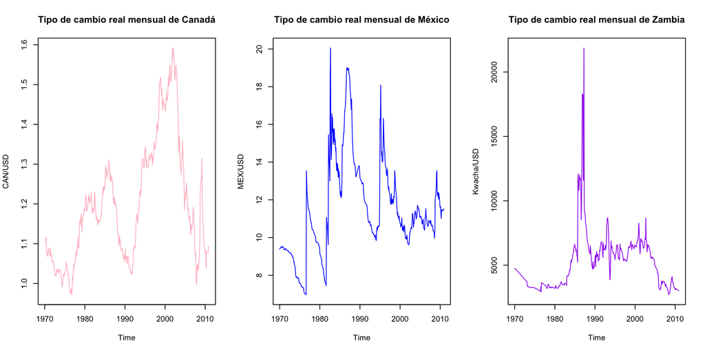

```r
tipo_de_cambio_canada <- ts(tipo_de_cambio$Canada,start = c(1970,01), frequency = 12)
tipo_de_cambio_zambia <- ts(tipo_de_cambio$Zambia,start = c(1970,01), frequency = 12)
tipo_de_cambio_mexico <- ts(tipo_de_cambio$Mexico,start = c(1970,01), frequency = 12)
par(mfrow = c(1,3))
plot(tipo_de_cambio_canada, main = "Tipo de cambio real mensual de Canadá", col = "pink", ylab="CAN/USD")
plot(tipo_de_cambio_mexico, main = "Tipo de cambio real mensual de México", col = "blue", ylab="MEX/USD")
plot(tipo_de_cambio_zambia, main = "Tipo de cambio real mensual de Zambia", col = "purple", ylab="Kwacha/USD")
```

```r
tipo_de_cambio_pais_promedio_anual <- function(x = tipo_de_cambio,pais = "Canada"){
  fecha <- as.Date(x$Date)
  tipo_de_cambio_mensual <-unname(unlist(x[pais]))

  datos_mensuales <- data_frame(fecha, tipo_de_cambio_mensual)

  datos_anuales <- datos_mensuales %>%
    group_by(year=floor_date(fecha, "year")) %>%
    summarize(media_anual = mean(tipo_de_cambio_mensual),
              desv_anual = sd(tipo_de_cambio_mensual))
  datos_anuales

}
canada_tc_prom_anual <- tipo_de_cambio_pais_promedio_anual(x = tipo_de_cambio,pais = "Canada")
```

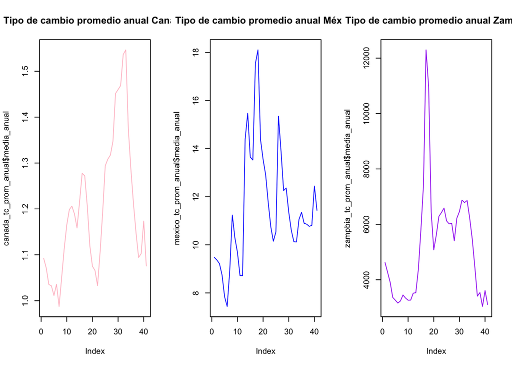

```r
mexico_tc_prom_anual <- tipo_de_cambio_pais_promedio_anual(x = tipo_de_cambio,pais = "Mexico")
zampbia_tc_prom_anual <- tipo_de_cambio_pais_promedio_anual(x = tipo_de_cambio,pais = "Zambia")

par(mfrow = c(1,3))
plot(canada_tc_prom_anual$media_anual, main="Tipo de cambio promedio anual Canadá", col = "pink", type = "l")
plot(mexico_tc_prom_anual$media_anual, main="Tipo de cambio promedio anual México", col = "blue", type = "l")
plot(zampbia_tc_prom_anual$media_anual, main="Tipo de cambio promedio anual Zambia", col = "purple", type ="l")
```

### Supuestos: Medias constantes en los renglones, Homogeneidad en los renglones y Simetría Estocástica

Para probar si las medias son constantes por en el tiempo, se grafican los tipos de cambio promedio ajustados anualmente.

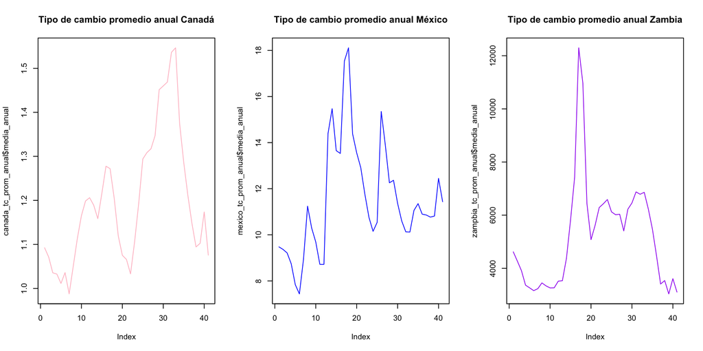

```r
tipo_de_cambio_pais_promedio_anual <- function(x = tipo_de_cambio,pais = "Canada"){
  fecha <- as.Date(x$Date)
  tipo_de_cambio_mensual <-unname(unlist(x[pais]))

  datos_mensuales <- data_frame(fecha, tipo_de_cambio_mensual)

  datos_anuales <- datos_mensuales %>%
    group_by(year=floor_date(fecha, "year")) %>%
    summarize(media_anual = mean(tipo_de_cambio_mensual),
              desv_anual = sd(tipo_de_cambio_mensual))
  datos_anuales

}
canada_tc_prom_anual <- tipo_de_cambio_pais_promedio_anual(x = tipo_de_cambio,pais = "Canada")
mexico_tc_prom_anual <- tipo_de_cambio_pais_promedio_anual(x = tipo_de_cambio,pais = "Mexico")
zampbia_tc_prom_anual <- tipo_de_cambio_pais_promedio_anual(x = tipo_de_cambio,pais = "Zambia")

par(mfrow = c(1,3))
plot(canada_tc_prom_anual$media_anual, main="Tipo de cambio promedio anual Canadá", col = "pink", type = "l")
plot(mexico_tc_prom_anual$media_anual, main="Tipo de cambio promedio anual México", col = "blue", type = "l")
plot(zampbia_tc_prom_anual$media_anual, main="Tipo de cambio promedio anual Zambia", col = "purple", type ="l")
```

Se observa que para estos tres países ejemplo, las medias anuales no son iguales, probablemente debido a múltiples factores políticos o socioeconómicos particulares a las economías. Por ello, se rompe el supuesto de medias constantes por renglon para convertirlo en medias constantes anuales.

Además, debido a que se tratan de una serie de tiempo, se reconoce que los renglones (tipos de cambio mensual), no son intercambiables.

En necesario además, centrar los datos para que el análisis sea más adecuado:

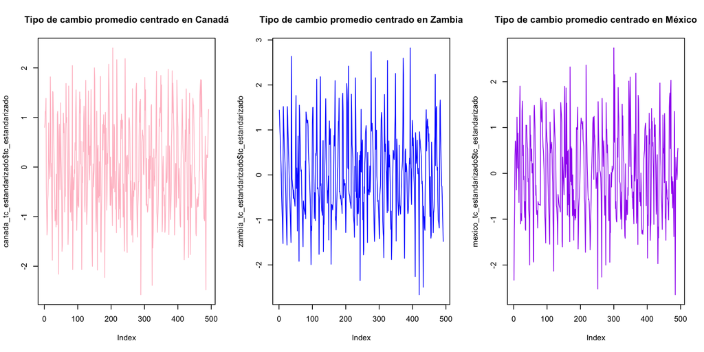

```r
tipo_de_cambio_pais_estandarizado <- function(x, pais){
    datos_mensuales <- x %>% select(Date,pais) %>% mutate(ano = year(Date)) %>% rename(tipo_de_cambio = pais)
    datos_anuales <- tipo_de_cambio_pais_promedio_anual(x,pais) %>% mutate(ano = year(year))

    datos_estandarizados <- datos_mensuales %>% left_join(datos_anuales, by=c("ano")) %>% mutate(tc_estandarizado = (tipo_de_cambio-media_anual) / desv_anual)

    datos_estandarizados %>% select(Date,ano, tc_estandarizado)
}
canada_tc_estandarizado <- tipo_de_cambio_pais_estandarizado(tipo_de_cambio, pais = "Canada")
zambia_tc_estandarizado <- tipo_de_cambio_pais_estandarizado(tipo_de_cambio, pais = "Zambia")
mexico_tc_estandarizado <- tipo_de_cambio_pais_estandarizado(tipo_de_cambio, pais = "Mexico")

par(mfrow = c(1,3))
plot(canada_tc_estandarizado$tc_estandarizado, main="Tipo de cambio promedio centrado en Canadá", type ="l", col= "pink")
plot(zambia_tc_estandarizado$tc_estandarizado, main="Tipo de cambio promedio centrado en Zambia",  type = "l",col= "blue")
plot(mexico_tc_estandarizado$tc_estandarizado, main="Tipo de cambio promedio centrado en México", type = "l", col= "purple")
```

Con lo anterior, se observa en las gráficas, una disminución de variabilidad en las observaciones.

Ahora, para verificar la simetría entre observaciones, será útil realizar una análisis de las autocorrelaciones: -Con los datos originales:

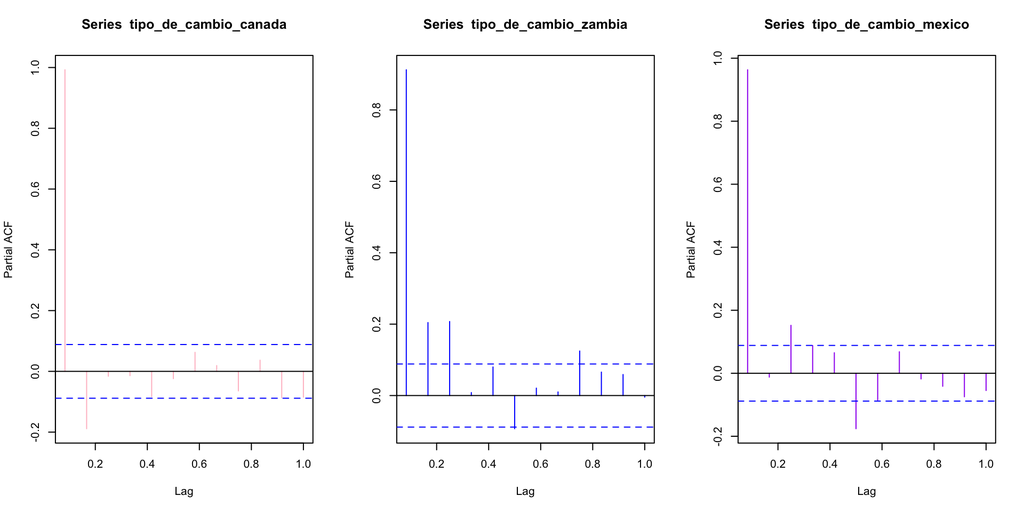

```r
library(forecast)

par(mfrow = c(1,3))
pacf(tipo_de_cambio_canada,lag.max = 12, plot = TRUE, col = "pink")
pacf(tipo_de_cambio_zambia, lag.max = 12, plot = TRUE, col = "blue")
pacf(tipo_de_cambio_mexico, lag.max = 12, plot = TRUE, col = "purple")
```

-Con los datos centrados en su media anual:

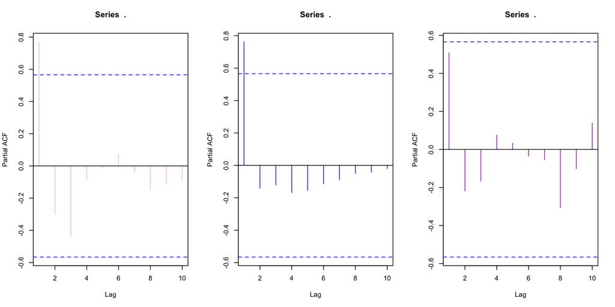

```r
par(mfrow = c(1,3))
canada_tc_estandarizado %>% filter(ano == 1970) %>% select(tc_estandarizado) %>% pacf(plot = TRUE, col = "pink")
zambia_tc_estandarizado %>% filter(ano == 1970) %>% select(tc_estandarizado) %>% pacf( plot = TRUE, col = "blue")
mexico_tc_estandarizado %>% filter(ano == 1970) %>% select(tc_estandarizado) %>% pacf(plot = TRUE, col = "purple")
```

Se observa que existen autocorrelaciones diferentes por país. Con las consideraciones anteriores, es necesario modificar el modelo:

1. Centrar los datos en la media anual (supuesto de varianza constante).
2. Ejecutar el modelo de PCA de manera anual (supuesto de la media constante).

## Modelo de Componentes Principales (3 economías)

Se comienza centrando los datos en la media y guardando la nueva base transformada.

```r
datos_estandarizados <- data_frame(
           ano = year(tipo_de_cambio$Date),
           canada = canada_tc_estandarizado$tc_estandarizado,
           mexico = mexico_tc_estandarizado$tc_estandarizado,
           zambia = zambia_tc_estandarizado$tc_estandarizado
           )

datos_estandarizados_2000 <- datos_estandarizados %>% filter(ano == 2000) %>% select(-ano)
head(datos_estandarizados_2000)
```

```
## # A tibble: 6 x 3
##   canada  mexico zambia
##    <dbl>   <dbl>  <dbl>
## 1 -1.32   0.857  -0.659
## 2 -1.26   0.533  -0.694
## 3 -0.879 -0.168  -0.771
## 4 -0.396 -0.0423 -0.871
## 5  0.428  0.605  -0.681
## 6 -0.308  2.19   -0.355
```

Se ejecuta la simulación de la gaussiana posterior ajustando los parámetros corresòndientes:

```r
data <- datos_estandarizados_2000
a0 <- 1
s0 <- 1/2
m0 <- matrix(0,ncol=1,nrow=ncol(data))
B0 <- diag(1,ncol=ncol(data),nrow=ncol(data))

gaussian.posterior <- function(data,m0,s0,a0,B0){
  xbar <- as.matrix(colMeans(data))
  S <- cov(data)
  n <- nrow(data)
  p <- ncol(data)

  # Posterior hiperparameters
  sn <- s0 + n
  an <- a0 + n/2
  mn <- (s0*m0 + n*xbar)/sn
  Bn <- B0 + (n/2)*(S + (s0/sn)*(xbar-m0)%*%t(xbar-m0)) # matriz de p x p

  output <- list(mn,sn,an,Bn)
  return(output)
}

output <- gaussian.posterior(data,m0,s0,a0,B0)
```

Para poder hacer inferencia concluyente se aumenta el número de simulaciones, por ejemplo a 1000:

```r
M <- 1000
mu.sim <- matrix(NA,nrow=M, ncol=ncol(data))
Lambda.sim <- array(NA,dim=c(M,ncol(data),ncol(data)))
e.sim <- matrix(NA,nrow=M, ncol=ncol(data))
V.sim <- array(NA,dim=c(M,ncol(data),ncol(data)))
C.sim <- array(NA,dim=c(M,nrow(data),ncol(data)))
m <- 1
X <- as.matrix(data)
for(m in 1:M){
  Lambda.sim[m,,] <- rWishart(1,
                              output[[3]],
                              output[[4]])


  mu.sim[m,] <- MASS::mvrnorm(1,
                              mu=output[[1]],
                              Sigma=solve(output[[2]]*Lambda.sim[m,,]),
                              tol = 1e-6)

  # Simulacion
  eigen_aux <- eigen(solve(Lambda.sim[m,,]))
  e.sim[m,] <- eigen_aux$values
  V.sim[m,,] <- eigen_aux$vectors
  C.sim[m,,] <- X %*% V.sim[m,,]
}
```

#### Análisis de Descomposición Espectral

Para poder vsualizar los componentes,se grafican los histogramas para los eigenvalores de las múltiples simulaciones.

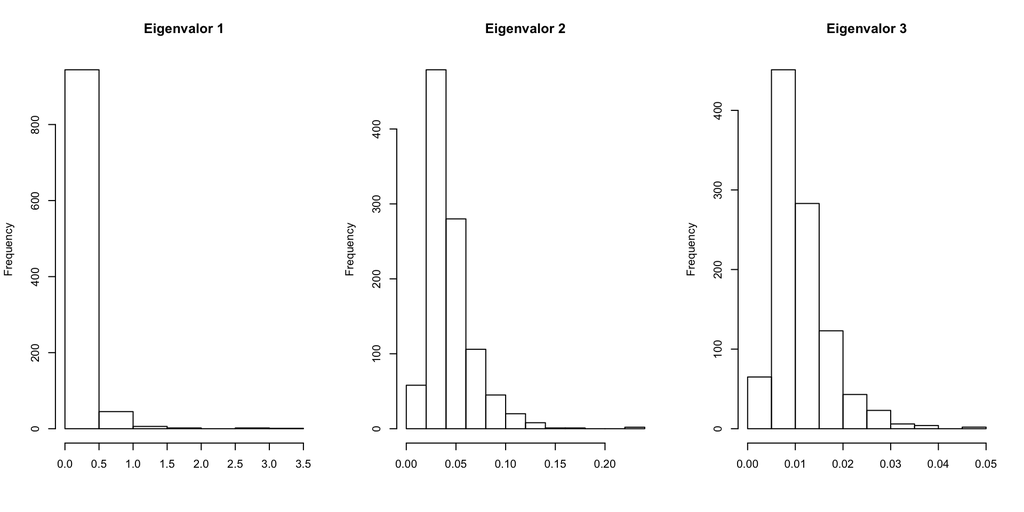

```r
par(mfrow = c(1,3))
for (i in 1:ncol(data)){
  hist(e.sim[,i], main = paste("Eigenvalor", i), xlab = "")
}
```

Con las gráficas anteriores, se observan a las distribuciones de los eigenvalores con forma gaussina no simétrica, por lo que se decidirá usar la moda como estimador puntual.

```r
getmode <- function(x) {
  uniqx <- unique(x)
  uniqx[which.max(tabulate(match(x, uniqx)))]
}
calcular_resumen_simulacion <- function(x){
  moda <- round(getmode(x),5)
  media <- round(mean(x),5)
  cuantiles <- round(quantile(x,c(0.025,0.975)),5)
  resumen <- data_frame("5%" = cuantiles[1],
                        "moda" = moda,
                        "media" = media,
                        "95%"= cuantiles[2])
  resumen
}

apply(e.sim, 2, calcular_resumen_simulacion)
```

```
## [[1]]
## # A tibble: 1 x 4
##     `5%`  moda media `95%`
##    <dbl> <dbl> <dbl> <dbl>
## 1 0.0492 0.164 0.190 0.616
##
## [[2]]
## # A tibble: 1 x 4
##     `5%`   moda  media `95%`
##    <dbl>  <dbl>  <dbl> <dbl>
## 1 0.0173 0.0409 0.0443 0.103
##
## [[3]]
## # A tibble: 1 x 4
##      `5%`   moda  media  `95%`
##     <dbl>  <dbl>  <dbl>  <dbl>
## 1 0.00416 0.0099 0.0112 0.0269
```

Se calculan ahora los pesos y se presenta en formato columnar para las tres economías:

```r
calcular_matriz_de_pesos <- function(x){
  matriz_de_modas_de_pesos <- matrix(NA,nrow = ncol(data), ncol = ncol(data))
  for (i in 1:ncol(data)){
    for (j in 1:ncol(data)) {
    matriz_de_modas_de_pesos[i,j] <- getmode(x[,i,j])
    }
  }
  rownames(matriz_de_modas_de_pesos) <- names(data)
  colnames(matriz_de_modas_de_pesos) <- paste("PC_",seq(1,ncol(data),1),sep = "")
  matriz_de_modas_de_pesos
}
calcular_matriz_de_pesos(C.sim)
```

```
##               PC_1       PC_2      PC_3
## canada -0.21449994 -0.6692582 -1.552944
## mexico  0.07623644 -0.6093867 -1.408435
## zambia  0.64276865 -0.2623991 -0.956178
```

Se indica además la moda correspondiente para cada eigenvalor generado con las simulaciones y se visualiza la cantidad de variabilidad que se acumula ordenada como es esperado de mayor a menor:

```r
moda_eigen <- c(getmode(e.sim[,1]),
      getmode(e.sim[,2]),
      getmode(e.sim[,3]))

resumen_eigen_valores <- as_data_frame(moda_eigen) %>% mutate(eig = seq(1,length(moda_eigen),1)) %>% mutate(variablidad = round(value / sum(value) * 100,2))
resumen_eigen_valores %>% select(eig, value, variablidad)
```

```
## # A tibble: 3 x 3
##     eig   value variablidad
##   <dbl>   <dbl>       <dbl>
## 1     1 0.164         76.3
## 2     2 0.0409        19.0
## 3     3 0.00990        4.61
```

Se calcula ahora la matriz de eigenvectores:

```r
calcular_matriz_de_eigen_vectores <- function(x){
  matriz_de_modas_de_eigen_vectores <- matrix(NA,nrow = ncol(data), ncol = ncol(data))
  for (i in 1:ncol(data)){
    for (j in 1:ncol(data)) {
    matriz_de_modas_de_eigen_vectores[i,j] <- getmode(x[,i,j])
    }
  }
  rownames(matriz_de_modas_de_eigen_vectores) <- names(data)
  colnames(matriz_de_modas_de_eigen_vectores) <- paste("PC_",seq(1,ncol(data),1),sep = "")
  matriz_de_modas_de_eigen_vectores
}
calcular_matriz_de_eigen_vectores(V.sim)
```

```
##              PC_1        PC_2       PC_3
## canada -0.2441415  0.81009759  0.5330449
## mexico -0.9011425  0.01353943 -0.4333116
## zambia -0.3582418 -0.58613870  0.7267078
```

### Modelos de Componentes Principales (Análisis de las 80 Economías y sus Tipos de Cambio)

Una vez analizado el problema en su versión sencilla con 3 países, se procede a realizarlo de manera generalizada para los 80 países. Para ello se sigue la misma estructura:

-Centrar los datos:

```r
paises_de_interes <- names(tipo_de_cambio)[-1]

lista_paies_estandarizados <- lapply(paises_de_interes, tipo_de_cambio_pais_estandarizado, x = tipo_de_cambio)

names(lista_paies_estandarizados) <- names(tipo_de_cambio)[-1]

df_tipo_de_cambio_estandarizado <- bind_rows(lista_paies_estandarizados, .id = "column_label") %>%
  spread(column_label,tc_estandarizado)
head(df_tipo_de_cambio_estandarizado)
```

```
## # A tibble: 6 x 82
##   Date                  ano Algeria Argentina Australia Austria Bangladesh
##   <dttm>              <dbl>   <dbl>     <dbl>     <dbl>   <dbl>      <dbl>
## 1 1970-01-01 00:00:00  1970   1.51     -0.432    -1.60  -2.32        1.18
## 2 1970-02-01 00:00:00  1970   1.24     -0.510    -1.44  -0.913       1.05
## 3 1970-03-01 00:00:00  1970   0.967    -0.693    -1.15   0.157       0.922
## 4 1970-04-01 00:00:00  1970   0.719    -0.694    -0.671  1.06        0.906
## 5 1970-05-01 00:00:00  1970   0.434    -0.785    -0.285  1.28        0.654
## 6 1970-06-01 00:00:00  1970   0.171     0.784     0.465 -0.0314      0.481
## # … with 75 more variables: Benin <dbl>, Brazil <dbl>, Cameroon <dbl>,
## #   Canada <dbl>, Chile <dbl>, `China,PR` <dbl>, Colombia <dbl>,
## #   Congo <dbl>, `Costa Rica` <dbl>, `Cote d'Ivoire` <dbl>, `Czech
## #   Rep` <dbl>, Denmark <dbl>, `Dominican Rep` <dbl>, Ecuador <dbl>,
## #   Egypt <dbl>, `El Salvador` <dbl>, EU12 <dbl>, Finland <dbl>,
## #   France <dbl>, Germany <dbl>, Ghana <dbl>, Greece <dbl>,
## #   Guatemala <dbl>, Honduras <dbl>, `Hong Kong` <dbl>, Hungary <dbl>,
## #   India <dbl>, Indonesia <dbl>, Ireland <dbl>, Israel <dbl>,
## #   Italy <dbl>, Jamaica <dbl>, Japan <dbl>, Jordan <dbl>, Kenya <dbl>,
## #   Korea <dbl>, Kuwait <dbl>, Luxembourg <dbl>, Malaysia <dbl>,
## #   Mexico <dbl>, Morocco <dbl>, Mozambique <dbl>, Netherlands <dbl>, `New
## #   Zealand` <dbl>, Nicaragua <dbl>, Nigeria <dbl>, Norway <dbl>,
## #   Pakistan <dbl>, Panama <dbl>, Paraguay <dbl>, Peru <dbl>,
## #   Philippines <dbl>, Poland <dbl>, Portugal <dbl>, Russia <dbl>, `Saudi
## #   Arabia` <dbl>, Senegal <dbl>, `Sierra Leone` <dbl>, Singapore <dbl>,
## #   `South Africa` <dbl>, Spain <dbl>, `Sri Lanka` <dbl>, Sweden <dbl>,
## #   Switzerland <dbl>, Syria <dbl>, Taiwan <dbl>, Tanzania <dbl>,
## #   Thailand <dbl>, `Trin/Tobago` <dbl>, Tunisia <dbl>, Turkey <dbl>,
## #   U.K. <dbl>, Uruguay <dbl>, Venezuela <dbl>, Zambia <dbl>
```

Nuevamente se analizarán los datos con el año 2000:

```r
df_tipo_de_cambio_estandarizado_2010 <- df_tipo_de_cambio_estandarizado %>%
  filter(ano == 2000) %>% select(-Date, -ano)
head(df_tipo_de_cambio_estandarizado_2010)
```

```
## # A tibble: 6 x 80
##   Algeria Argentina Australia Austria Bangladesh  Benin  Brazil Cameroon
##     <dbl>     <dbl>     <dbl>   <dbl>      <dbl>  <dbl>   <dbl>    <dbl>
## 1 -2.11      -1.92     -1.84   -1.67      -1.23  -1.35  -0.381    -1.77
## 2 -1.32      -1.53     -1.13   -1.20      -0.991 -0.654 -0.764    -1.01
## 3 -0.891     -0.626    -0.543  -0.796     -0.738 -0.641 -1.20     -0.804
## 4 -0.319     -0.512    -0.262  -0.419     -0.725 -0.438 -0.818    -0.477
## 5  0.213     -0.168     0.263   0.322     -0.694  0.336  0.358     0.159
## 6  0.0526     0.319    -0.286  -0.560     -0.534 -1.12   0.0858   -0.377
## # … with 72 more variables: Canada <dbl>, Chile <dbl>, `China,PR` <dbl>,
## #   Colombia <dbl>, Congo <dbl>, `Costa Rica` <dbl>, `Cote
## #   d'Ivoire` <dbl>, `Czech Rep` <dbl>, Denmark <dbl>, `Dominican
## #   Rep` <dbl>, Ecuador <dbl>, Egypt <dbl>, `El Salvador` <dbl>,
## #   EU12 <dbl>, Finland <dbl>, France <dbl>, Germany <dbl>, Ghana <dbl>,
## #   Greece <dbl>, Guatemala <dbl>, Honduras <dbl>, `Hong Kong` <dbl>,
## #   Hungary <dbl>, India <dbl>, Indonesia <dbl>, Ireland <dbl>,
## #   Israel <dbl>, Italy <dbl>, Jamaica <dbl>, Japan <dbl>, Jordan <dbl>,
## #   Kenya <dbl>, Korea <dbl>, Kuwait <dbl>, Luxembourg <dbl>,
## #   Malaysia <dbl>, Mexico <dbl>, Morocco <dbl>, Mozambique <dbl>,
## #   Netherlands <dbl>, `New Zealand` <dbl>, Nicaragua <dbl>,
## #   Nigeria <dbl>, Norway <dbl>, Pakistan <dbl>, Panama <dbl>,
## #   Paraguay <dbl>, Peru <dbl>, Philippines <dbl>, Poland <dbl>,
## #   Portugal <dbl>, Russia <dbl>, `Saudi Arabia` <dbl>, Senegal <dbl>,
## #   `Sierra Leone` <dbl>, Singapore <dbl>, `South Africa` <dbl>,
## #   Spain <dbl>, `Sri Lanka` <dbl>, Sweden <dbl>, Switzerland <dbl>,
## #   Syria <dbl>, Taiwan <dbl>, Tanzania <dbl>, Thailand <dbl>,
## #   `Trin/Tobago` <dbl>, Tunisia <dbl>, Turkey <dbl>, U.K. <dbl>,
## #   Uruguay <dbl>, Venezuela <dbl>, Zambia <dbl>
```

Se ingresan los parámetros de la siumulación de la posterior:

```r
data <- df_tipo_de_cambio_estandarizado_2010
a0 <- 1
s0 <- 1/2
m0 <- matrix(0,ncol=1,nrow=ncol(data))
B0 <- diag(1,ncol=ncol(data),nrow=ncol(data))

gaussian.posterior <- function(data,m0,s0,a0,B0){
  xbar <- as.matrix(colMeans(data))
  S <- cov(data)
  n <- nrow(data)
  p <- ncol(data)

  sn <- s0 + n
  an <- a0 + n/2
  mn <- (s0*m0 + n*xbar)/sn
  Bn <- B0 + (n/2)*(S + (s0/sn)*(xbar-m0)%*%t(xbar-m0))

  output <- list(mn,sn,an,Bn)
  return(output)
}

output <- gaussian.posterior(data,m0,s0,a0,B0)

M <- 1000
mu.sim <- matrix(NA,nrow=M, ncol=ncol(data))
Lambda.sim <- array(NA,dim=c(M,ncol(data),ncol(data)))
e.sim <- matrix(NA,nrow=M, ncol=ncol(data))
V.sim <- array(NA,dim=c(M,ncol(data),ncol(data)))
C.sim <- array(NA,dim=c(M,nrow(data),ncol(data)))
m <- 1
X <- as.matrix(data)


for(m in 1:M){
  Lambda.sim[m,,] <- rWishart(1,
                              492,
                              output[[4]])
  mu.sim[m,] <- MASS::mvrnorm(1,
                              mu=output[[1]],
                              Sigma=solve(output[[2]]*Lambda.sim[m,,]),
                              tol = 1e-6)


  eigen_aux <- eigen(solve(Lambda.sim[m,,]))
  e.sim[m,] <- eigen_aux$values
  V.sim[m,,] <- eigen_aux$vectors
  C.sim[m,,] <- X %*% V.sim[m,,]
}
```

Una vez concluida la simulación, se procede a realizar gráficas útiles para la interpretación de eigenvalores de las 80 economías:

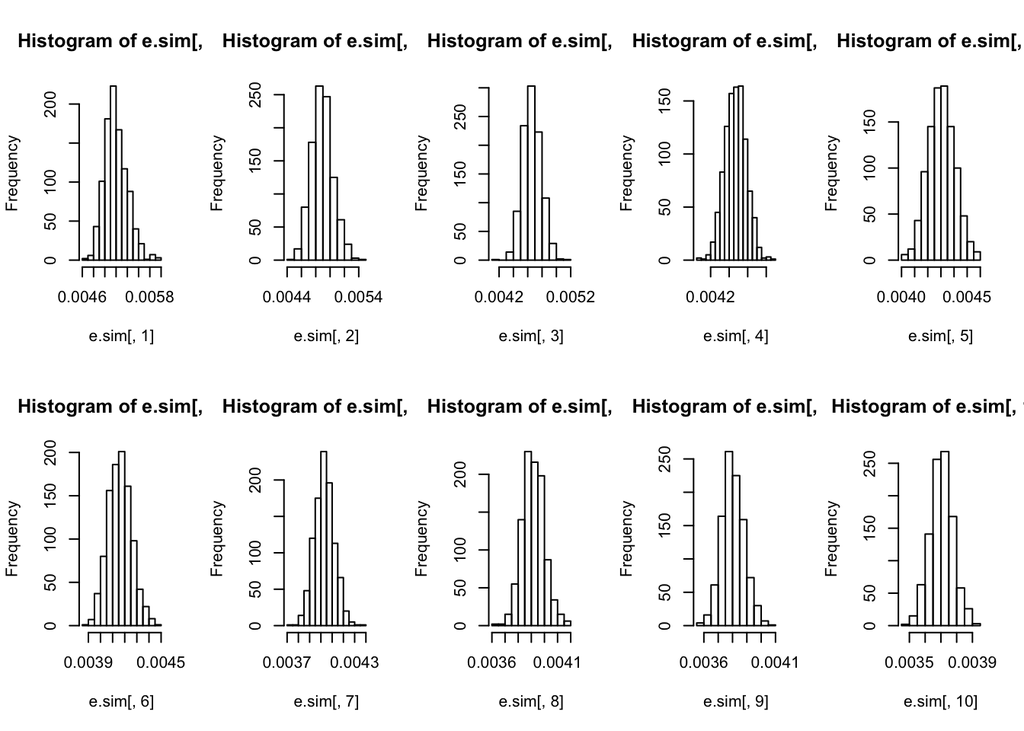

```r
par(mfrow = c(2,5))
hist(e.sim[,1])
hist(e.sim[,2])
hist(e.sim[,3])
hist(e.sim[,4])
hist(e.sim[,5])
hist(e.sim[,6])
hist(e.sim[,7])
hist(e.sim[,8])
hist(e.sim[,9])
hist(e.sim[,10])
```

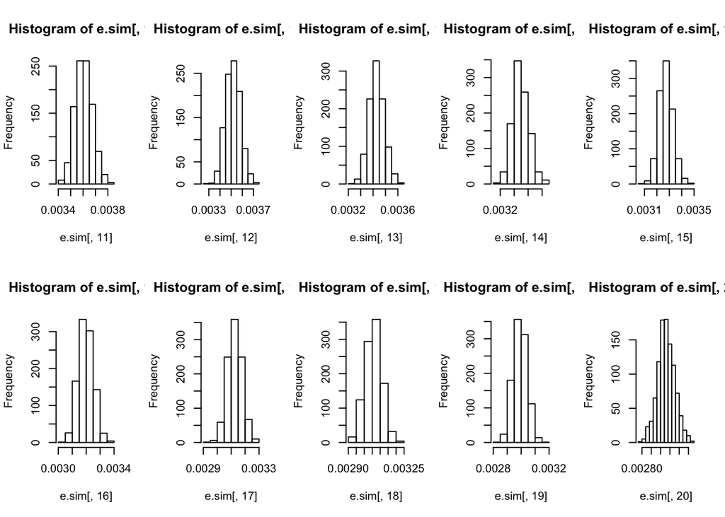

```r
par(mfrow = c(2,5))
hist(e.sim[,11])
hist(e.sim[,12])
hist(e.sim[,13])
hist(e.sim[,14])
hist(e.sim[,15])
hist(e.sim[,16])
hist(e.sim[,17])
hist(e.sim[,18])
hist(e.sim[,19])
hist(e.sim[,20])
```

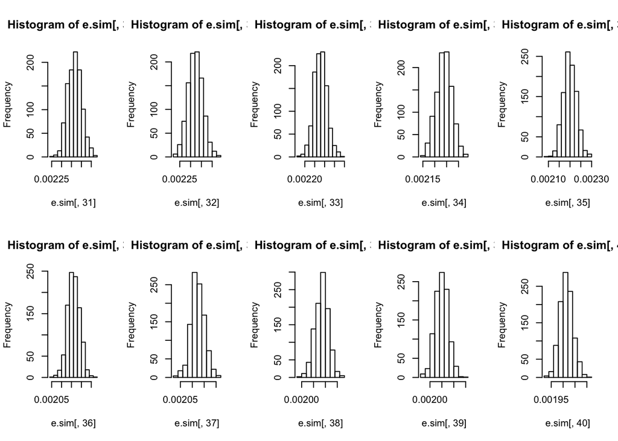

```r
par(mfrow = c(2,5))
hist(e.sim[,31])
hist(e.sim[,32])
hist(e.sim[,33])
hist(e.sim[,34])
hist(e.sim[,35])
hist(e.sim[,36])
hist(e.sim[,37])
hist(e.sim[,38])
hist(e.sim[,39])
hist(e.sim[,40])
```

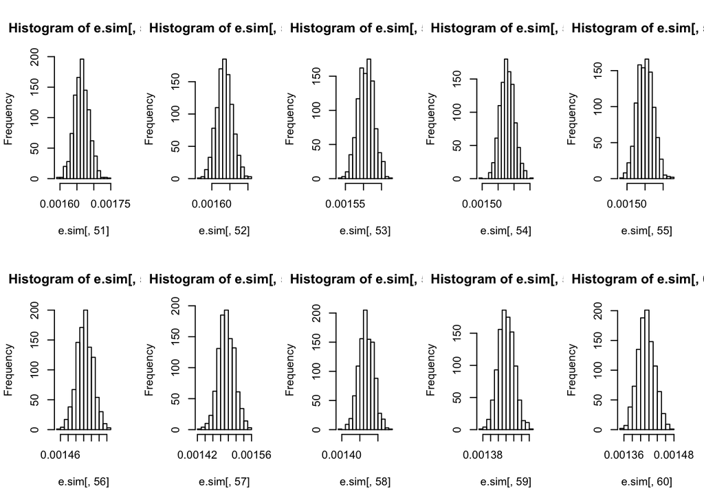

```r
par(mfrow = c(2,5))
hist(e.sim[,51])
hist(e.sim[,52])
hist(e.sim[,53])
hist(e.sim[,54])
hist(e.sim[,55])
hist(e.sim[,56])
hist(e.sim[,57])
hist(e.sim[,58])
hist(e.sim[,59])
hist(e.sim[,60])
```

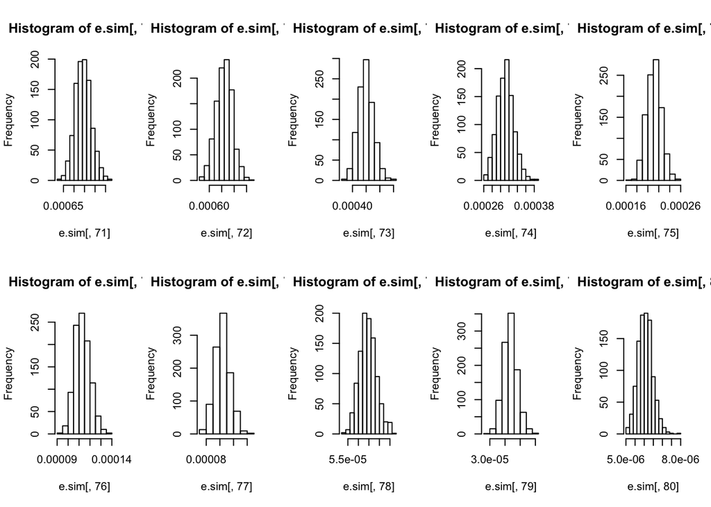

```r
par(mfrow = c(2,5))
hist(e.sim[,71])
hist(e.sim[,72])
hist(e.sim[,73])
hist(e.sim[,74])
hist(e.sim[,75])
hist(e.sim[,76])
hist(e.sim[,77])
hist(e.sim[,78])
hist(e.sim[,79])
hist(e.sim[,80])
```

Se calcula la matriz de eigenvectores para los 80 países también:

```r
calcular_matriz_de_eigen_vectores <- function(x){
  matriz_de_modas_de_eigen_vectores <- matrix(NA,nrow = ncol(data), ncol = ncol(data))
  for (i in 1:ncol(data)){
    for (j in 1:ncol(data)) {
    matriz_de_modas_de_eigen_vectores[i,j] <- getmode(x[,i,j])
    }
  }
  rownames(matriz_de_modas_de_eigen_vectores) <- names(data)
  colnames(matriz_de_modas_de_eigen_vectores) <- paste("PC_",seq(1,ncol(data),1),sep = "")
  matriz_de_modas_de_eigen_vectores
}
head(calcular_matriz_de_eigen_vectores(V.sim))
```

```
##                   PC_1        PC_2        PC_3        PC_4        PC_5
## Algeria    -0.04066844  0.10038349 -0.02393856  0.15002283 -0.05131466
## Argentina   0.13086399 -0.05869298 -0.08717266 -0.07828019 -0.07788765
## Australia   0.05382195  0.01054618 -0.03973278 -0.02592341 -0.00169386
## Austria    -0.06048243  0.04590856 -0.29280320 -0.12968609 -0.01519556
## Bangladesh -0.11560720  0.07314071 -0.05132446  0.03778499 -0.19843009
## Benin       0.02191006 -0.03871250  0.03504870  0.01807645 -0.05620225
##                   PC_6        PC_7       PC_8        PC_9       PC_10
## Algeria     0.09648880 -0.02629254  0.2079915  0.02023227 -0.14331850
## Argentina  -0.07082153 -0.06776242  0.0715372  0.17915948 -0.01408774
## Australia   0.08605665  0.07410209 -0.1498600  0.11785867 -0.14571772
## Austria    -0.07552948 -0.15181647  0.1240128  0.06506922  0.01802645
## Bangladesh  0.21353277  0.09065034 -0.1418922 -0.05134359 -0.16122888
## Benin       0.02471058 -0.05435661 -0.2245673  0.02748763  0.09197751
##                   PC_11        PC_12       PC_13       PC_14       PC_15
## Algeria     0.015907188  0.015445321 -0.01613409  0.01572813  0.01092836
## Argentina  -0.006194226 -0.009633416  0.01433226  0.12890586  0.01543610
## Australia  -0.013537530  0.192358847  0.23086535 -0.08579329 -0.06383729
## Austria    -0.105513543 -0.071869474  0.19406567  0.07394150 -0.10669265
## Bangladesh  0.183127908 -0.202674726 -0.15887269 -0.04967836  0.05060081
## Benin      -0.033442583 -0.150894044  0.19297757  0.19358657 -0.04320925
##                  PC_16       PC_17        PC_18        PC_19       PC_20
## Algeria     0.29971580  0.05090677  0.004970818  0.092927997  0.06353383
## Argentina  -0.01166386  0.07912388  0.026767737  0.006344632 -0.07078044
## Australia   0.08913310 -0.03317007  0.023999464  0.016391273 -0.05770557
## Austria    -0.12163976 -0.18427482 -0.154813363  0.033860134 -0.04294544
## Bangladesh  0.16711397  0.12371534 -0.165283247 -0.148767900 -0.11533804
## Benin      -0.06657790 -0.11749576  0.110505585 -0.059729072  0.20195564
##                  PC_21       PC_22        PC_23        PC_24       PC_25
## Algeria     0.01499315  0.11082670 -0.002818538 -0.167972384  0.16918222
## Argentina  -0.09198135  0.11023113  0.174377435  0.274904306  0.10668110
## Australia   0.18130172 -0.15426389 -0.064473990 -0.141890983  0.11022659
## Austria    -0.19083552  0.18462039 -0.064321618 -0.239253324  0.10341323
## Bangladesh -0.11323865 -0.07756446 -0.088464486  0.006096563 -0.07392433
## Benin       0.05344652  0.03131040 -0.209533562  0.074784522 -0.17977498
##                  PC_26       PC_27       PC_28       PC_29       PC_30
## Algeria    -0.15412951  0.25679079  0.11001044 -0.16156977 -0.02722944
## Argentina  -0.03773247  0.02445768  0.21920742 -0.01773977  0.08457385
## Australia  -0.20625838  0.07700152 -0.02098012 -0.05701037 -0.27075157
## Austria     0.06296573 -0.15134620  0.10650326 -0.14337595  0.02246867
```

[output cut: 57 more lines]

```
## Benin      -0.002924423  0.069704208 -0.01326871 -0.03765838 -1.835440e-01
##                  PC_71       PC_72        PC_73         PC_74       PC_75
## Algeria    -0.03600393 -0.04371697  0.013535224 -0.0001461392 -0.01560232
## Argentina  -0.05972323  0.09477545  0.099948819  0.1499601798 -0.01693202
## Australia   0.05262234  0.03893379 -0.074001398  0.0535311196  0.01923851
## Austria    -0.05873491  0.02512620  0.007511138 -0.0748084172 -0.04610083
## Bangladesh  0.04217143  0.03455350  0.137478945  0.0831202419  0.01290646
## Benin       0.03698798 -0.02055041 -0.014677778 -0.1651989677 -0.01945772
##                  PC_76        PC_77       PC_78       PC_79      PC_80
## Algeria    -0.02884115  0.004077922  0.04451944 -0.10795170 -0.1256726
## Argentina  -0.02885125 -0.024326595  0.11875009 -0.01772549 -0.1298101
## Australia   0.11422366 -0.124904795 -0.03302677 -0.01535940 -0.1251437
## Austria     0.07452202 -0.045271777 -0.07125852 -0.06249682 -0.1252836
## Bangladesh -0.11024965 -0.004072207 -0.10533431  0.03593397 -0.1231547
## Benin       0.06604220 -0.097005165 -0.19235624 -0.04828345 -0.1098202
```

```r
df_pesos_pc1 <- calcular_matriz_de_eigen_vectores(V.sim)[,1]
```

Con lo anterior se concluye la parte de simulación y modelación para proceder a responder las preguntas planteadas inicialmente.

# Países con las menores y mayores economías

```r
sort(df_pesos_pc1)
```

```
##  Saudi Arabia         Congo         Ghana       Morocco          U.K.
##  -0.277149948  -0.250941247  -0.223065165  -0.204677482  -0.182976213
##        Zambia        Taiwan        Turkey   Philippines   Switzerland
##  -0.179569684  -0.165792731  -0.161543656  -0.156799301  -0.155599480
##      Honduras     Indonesia Dominican Rep   Trin/Tobago         Spain
##  -0.150270616  -0.132058575  -0.121729222  -0.121261540  -0.115909234
##    Bangladesh        Brazil         Kenya        Israel      Colombia
##  -0.115607196  -0.104587965  -0.104018268  -0.093621967  -0.088313267
##       Finland Cote d'Ivoire     Sri Lanka        Poland        Canada
##  -0.082929337  -0.080718694  -0.078556112  -0.075888682  -0.071960313
##       Austria       Senegal      Cameroon       Algeria        Greece
##  -0.060482432  -0.049389411  -0.041734591  -0.040668440  -0.034817127
##        Jordan        Russia       Nigeria         India    Mozambique
##  -0.032548048  -0.030063984  -0.025960049  -0.017218698  -0.011048367
##    Luxembourg        Kuwait          Peru       Tunisia          EU12
##  -0.001103498   0.004529760   0.009788053   0.012051734   0.015756155
##         Benin      Pakistan         Japan     Venezuela       Denmark
##   0.021910059   0.037505354   0.038028054   0.041465007   0.041486894
##      Thailand       Ecuador   El Salvador        France         Egypt
##   0.042189133   0.042716091   0.044531222   0.048391911   0.048568064
##      China,PR     Guatemala     Australia  South Africa      Tanzania
##   0.053098475   0.053447791   0.053821949   0.057239709   0.064011307
##         Syria   New Zealand        Norway         Korea     Hong Kong
##   0.071336701   0.075380288   0.075634949   0.080898212   0.085066764
##       Jamaica        Panama       Germany        Mexico        Sweden
##   0.088204562   0.089223695   0.090804924   0.091296962   0.094317760
##       Hungary     Singapore      Paraguay     Czech Rep   Netherlands
##   0.098579440   0.102101500   0.110365900   0.115994813   0.116307579
##      Malaysia    Costa Rica     Argentina      Portugal         Italy
##   0.118973432   0.121773132   0.130863985   0.133246979   0.151577672
##  Sierra Leone       Ireland     Nicaragua       Uruguay         Chile
##   0.151709375   0.158189975   0.165251229   0.217619097   0.218336665
```

```r
print("PAIS CON LA MENOR ECONOMIA:  ")
```

```
## [1] "PAIS CON LA MENOR ECONOMIA:  "
```

```r
which.min(df_pesos_pc1)
```

```
## Saudi Arabia
##           61
```

```r
print("PAIS CON LA MAYOR ECONOMIA:  ")
```

```
## [1] "PAIS CON LA MAYOR ECONOMIA:  "
```

```r
which.max(df_pesos_pc1)
```

```
## Chile
##    10
```

# Países más consistentes

Para encontrar esto, se asume consistencia como frecuncia de aparición en las simulaciones y para ello se realiza lo siguiente:

```r
eigenvectores_absoluto<- abs(calcular_matriz_de_eigen_vectores(V.sim))
paises <- rownames(eigenvectores_absoluto)
id <- seq(1,80,1)

id_paises <- as.data.frame(cbind(id, paises))


vector_max <- vector(length = 80)
for(i in 1:80){
  vector_max[i] <- which.max(eigenvectores_absoluto[,i])
  rownames(vector_max)
}

vector_max <- as.data.frame(vector_max) %>% rename(id=vector_max)
#vector_max

freq <- group_by(vector_max, id) %>% count()
freq_final <- arrange(freq, n)
head(freq_final)
```

```
## # A tibble: 6 x 2
## # Groups:   id [6]
##      id     n
##   <int> <int>
## 1     3     1
## 2     4     1
## 3     6     1
## 4     7     1
## 5     9     1
## 6    10     1
```

```r
tail(freq_final)
```

```
## # A tibble: 6 x 2
## # Groups:   id [6]
##      id     n
##   <int> <int>
## 1    76     2
## 2    22     3
## 3    28     3
## 4    46     3
## 5    59     3
## 6    65     3
```

```r
filter(id_paises, id==10)
```

```
##   id paises
## 1 10  Chile
```

```r
filter(id_paises, id==12)
```

```
##   id   paises
## 1 12 Colombia
```

```r
filter(id_paises, id==19)
```

```
##   id  paises
## 1 19 Ecuador
```

```r
filter(id_paises, id==50)
```

```
##   id    paises
## 1 50 Nicaragua
```

```r
filter(id_paises, id==71)
```

```
##   id paises
## 1 71 Taiwan
```